# Pset Prediction Assignment Writeup

Roman Abashin

3/31/2019

# Loading data and libraries

This assignment is about building a robust model to predict physical activity type from data collected by a wearable activity tracker like a Fitbit.

# Explorational Data Analysis

## Target Variable

Our target variable, `classe`, is a 5-level factor variable that indicates the type of activity a person is doing.

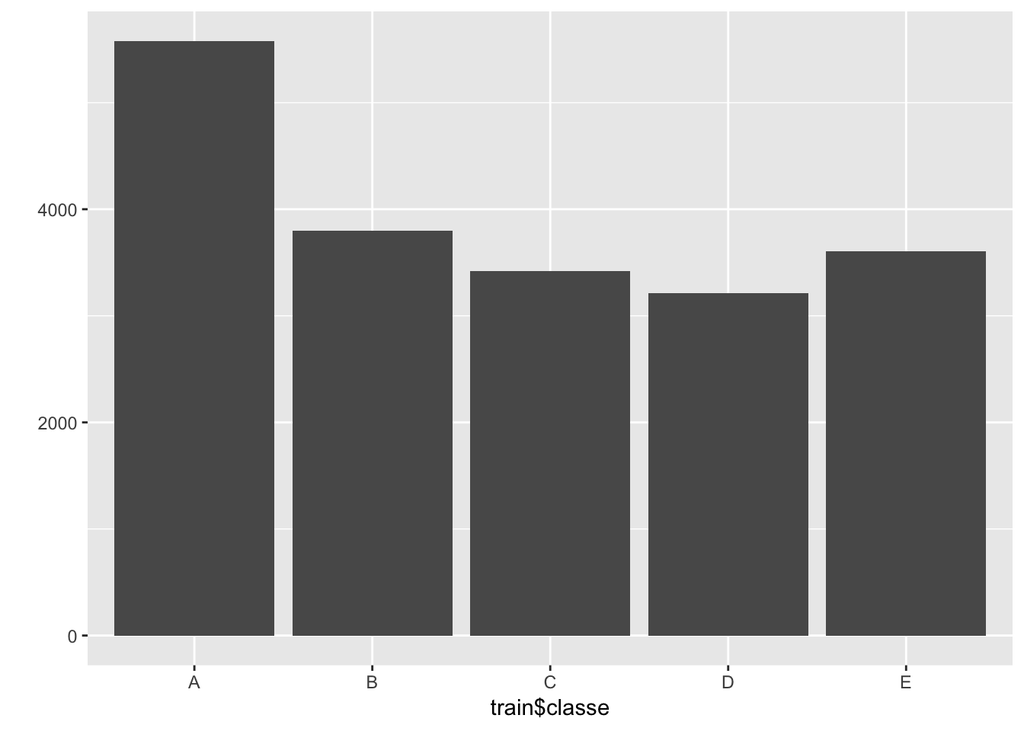

```r
qplot(train$classe)
```

Running `qplot(train$classe)` (above) or `table(t(colwise(class)(train)))` shows two things:

- First, that there are no missing values.
- Second, that we have a slight imbalance in our training data.

The latter will be ignored for our first model, but can definitely be a point for further improvement.

Furthermore, `class(data$classe)` shows that our target variable is encoded as a character. This will be needed to be dealt with.

## Features

Running `table(t(colwise(class)(train)))` shows, that we have multiple numeric features that are encoded as character. Further exploration shows that all of the character-encoded seem to have missing value. There is no indiciation whether those are to be treated as `0` (no value recorded) or `NA` (missing from the data).

Furthermore, there seem to be two parts to the feature data:

- Attributes of the observation (e.g., `id`, `user_name`, or `cvtd_timestamp`) in variables 1-7
- Observed values (e.g., `pitch_belt`) in variables 8-159

This leads to the conclusion that

1. The variables 1-7 should not be used for a first generalized model;  
   This also means that there is an opportunity for later optimization by, e.g., taking into account the time of day of the exercise,
2. The variables 8-159 should be encoded into `numeric`;  
   This will also lead to the character-encoded empty string values to be converted to NA. Specialized models would also maybe work with `0` values.

## NA values

```r
na_test <- train
na_test[, 8:159] <- lapply(na_test[, 8:159], as.numeric)
data.frame(id = 1:160, n = sapply(na_test, function(y) sum(length(which(is.na(y)))) / nrow(na_test))) %>%
    filter(n > 0.95) %>%        # remove for full list
    nrow()                      # remove for full list
```

```
## [1] 100
```

A test for NA values in numeric-encoded variables also shows that 100 variables are 95% `NA`. This also leads to the conclusion that those columns can be probably be safely eliminated for a first generalized model.

## Variables with near-zero variance

Using `nearZeroVar(train)` the training data can be tested for variables that do not show a lot of variation. Many of those variables are probably sparse, so this test should be repeated after removing the sparse variables with >95% `NA` values.

# Data cleaning

## Encode feature variables as numeric,

```r
train[, 8:159] <- lapply(train[, 8:159], as.numeric)
```

This has also creates some sparse columns (empty strings were coerced into `NA`) which need to be dealt with.

## Remove sparse variables

```r
nas <- data.frame(id = 1:160,
                  n = sapply(train, function(y) sum(length(which(is.na(y)))) / nrow(train))) %>%
    filter(n > 0.95)
train <- train[, -as.vector(nas$id)]
```

Furthermore, we should ensure that there are not variables with low variance left.

```r
nearZeroVar(train)
```

```
## [1] 6
```

The only near-zero variable is an attribute that will not be used for the model. Therefore, it can safely be left as-is.

## Encode target variable as factor

```r
train[, 60] <- factor(train[, 60], levels = c(LETTERS[1:5]))
```

# Model

## Build model

Support vector machine multi-classification. Should there unexpectedly be more `NA` values, those will be omitted.

```r
fit <- svm(classe ~ ., data = train[, 7:60], na.action = na.omit)
```

## Test model on training set

```r
confusionMatrix(train$classe, predict(fit, train))$overall[1]
```

```
##  Accuracy
## 0.9624401
```

Our model shows 96% accuracy on the training set. The accuracy on the test set will probably be lower.

# Prediction

## Prepare test set

```r
test[, 8:159] <- lapply(test[, 8:159], as.numeric)
test <- test[, -as.vector(nas$id)]
```

## Predict values

```r
predict(fit, test)
```

```
##  1  2  3  4  5  6  7  8  9 10 11 12 13 14 15 16 17 18 19 20
##  B  A  B  A  A  E  D  B  A  A  B  C  B  A  E  E  A  B  B  B
## Levels: A B C D E
```